# Harnessing big data for agricultural excellence

# Big data and AI in agriculture

## Smart farming

We already talked about data collection thanks to the Internet of Things (e.g. moisture sensors)

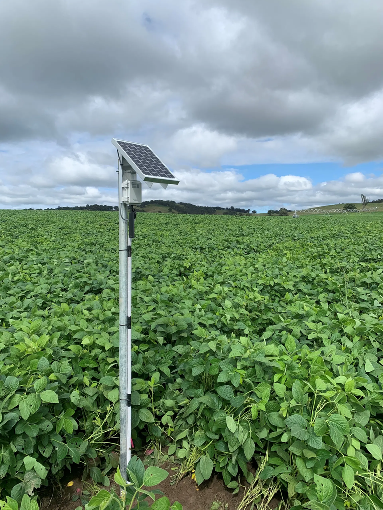

## Smart farming

But this goes much further as AI algorithms can be used for “precision agriculture”

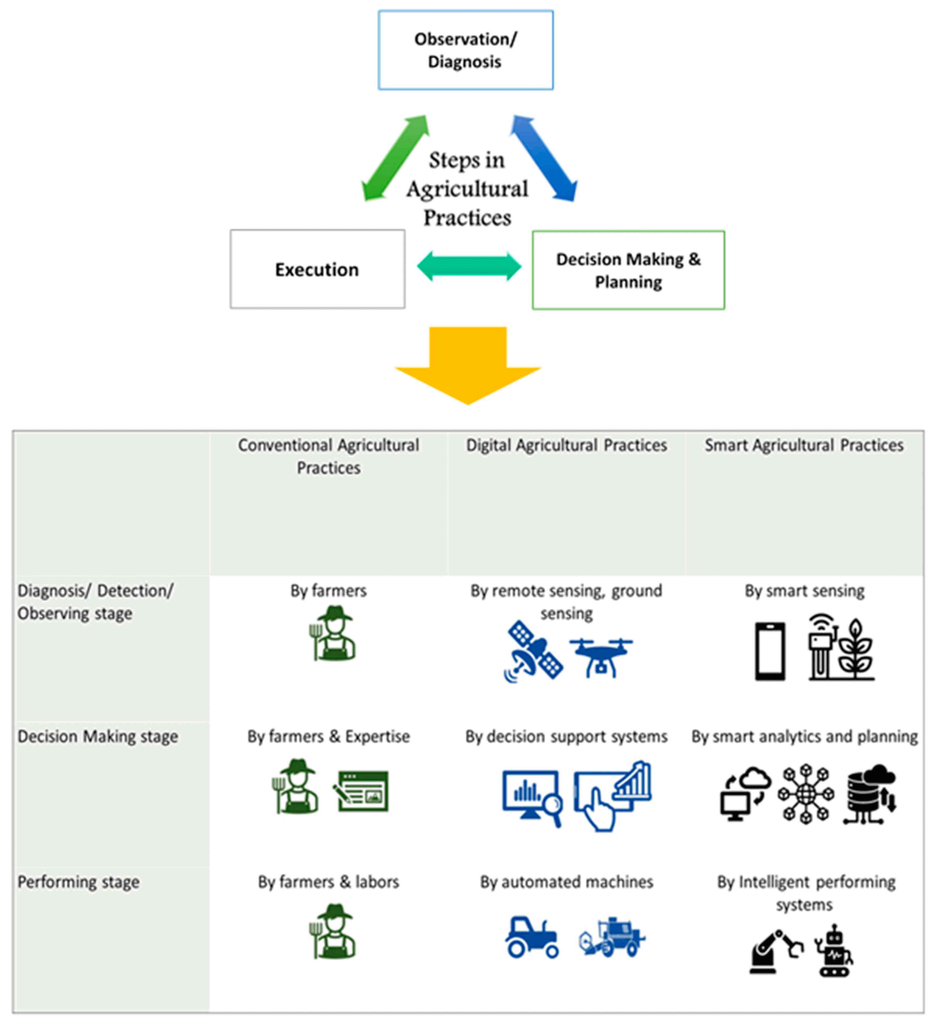

[Karunathilake, E. M. B. M., Le, A. T., Heo, S., Chung, Y. S., & Mansoor, S. (2023). The path to smart farming: Innovations and opportunities in precision agriculture. Agriculture, 13(8), 1593.](https://www.mdpi.com/2077-0472/13/8/1593)

## Smart farming

Many AI tools are involved in improving all domains of agriculture, from irrigation management to supply chain and demand forecasting

The benefits are huge for both farmers (increased yields, reduced costs, better planning) and the environment (optimization of resources and pesticide use)

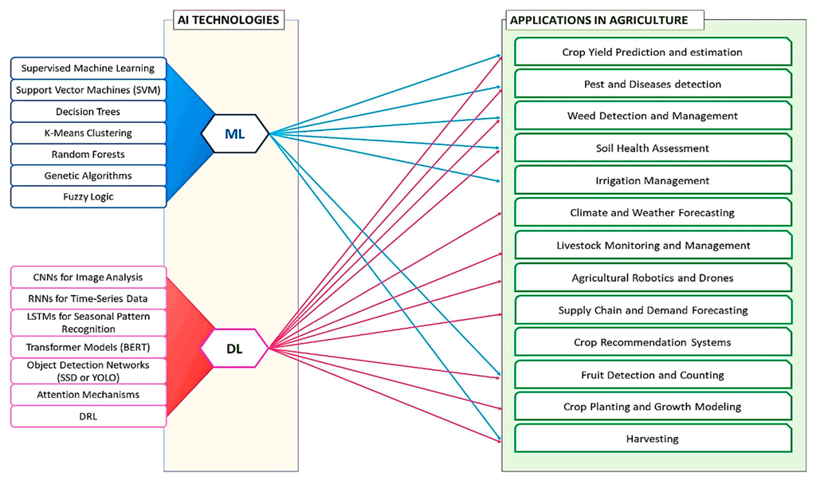

[Karunathilake, E. M. B. M., Le, A. T., Heo, S., Chung, Y. S., & Mansoor, S. (2023). The path to smart farming: Innovations and opportunities in precision agriculture. Agriculture, 13(8), 1593.](https://www.mdpi.com/2077-0472/13/8/1593)

## Decision making

### Before

Farmers had to make decisions as best they could based on their experience and their limited data

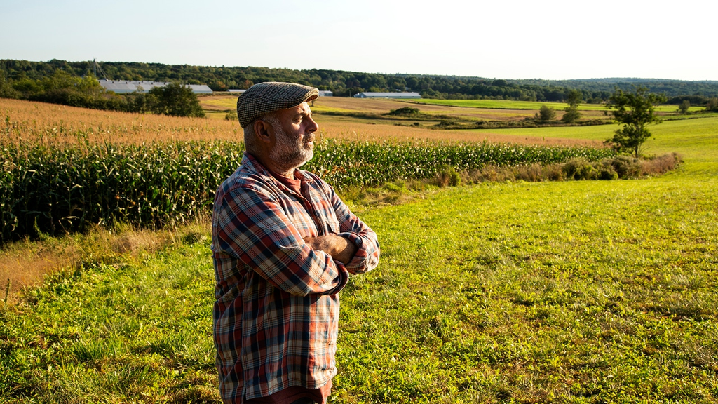

## Decision making

### Before

Farmers had to take decisions as best they could based on their experience and their limited data

### Now

Farmers can use powerful models to make informed decisions in real time. This can be followed by the automation of some action (e.g. watering)

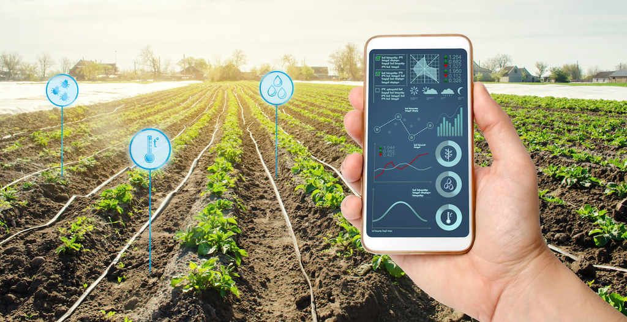

## Livestock monitoring

### A case study

Livestock successfully monitored remotely via sound sensors and algorithms for background noise filtering

Animal welfare and efficiency improvements

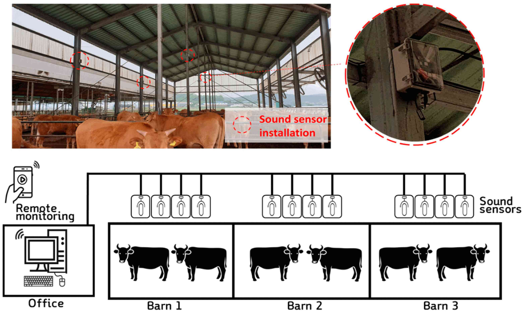

[Jung, D. H., Kim, N. Y., Moon, S. H., Jhin, C., Kim, H. J., Yang, J. S., … & Park, S. H. (2021). Deep learning-based cattle vocal classification model and real-time livestock monitoring system with noise filtering. Animals, 11(2), 357.](https://www.mdpi.com/2076-2615/11/2/357)

## Market analysis and supply chain optimization

### A review

Systematic literature review of peer-reviewed articles and conference papers published between 2014 and 2024<sup>1</sup> showed large improvements of demand forecasting accuracy and supply chain optimization

Real time data analysis helped with predictive maintenance, market volatility, resource constraints, and climate variability

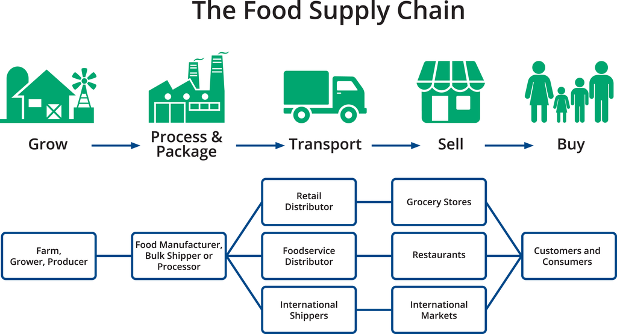

[^1]: [Elufioye, O. A., Ike, C. U., Odeyemi, O., Usman, F. O., & Mhlongo, N. Z. (2024). Ai-Driven predictive analytics in agricultural supply chains: a review: assessing the benefits and challenges of ai in forecasting demand and optimizing supply in agriculture. Computer Science & IT Research Journal, 5(2), 473-497.](https://fepbl.com/index.php/csitrj/article/view/817)

## Challenges

There are challenges to the implementation of such transformative methods

- Infrastructure development
- Skill gaps among agricultural professionals

**We are here to help!**

[figure not shown]

[figure not shown]

**Come to session 2 tomorrow!**

## Session 2

Join us **tomorrow at 11am in the Mount Baker Room** for our 2<sup>nd</sup> session:

Diagnosing and implementing big data solutions

We will have an interactive workshop to:

- Brainstorm on how big data can benefit your operation
- Help you make the transition to smart farming

# Resources

## Getting in touch

### SFU’s Big Data Hub

[Website](https://www.sfu.ca/big-data.html)  
[Contact us](https://www.sfu.ca/big-data/about-us/contact-us.html)  
[Consultation services](https://www.sfu.ca/big-data/about-us/consultation-services.html)  
Partnerships

### BCCAI

[Website](https://www.sfu.ca/agritech-innovation.html)  
[Contact us](https://www.sfu.ca/agritech-innovation/connect/contact.html)  
[Agritech development program](https://www.sfu.ca/agritech-innovation/programs/agritech-development-program/application.html)  
[Training](https://www.sfu.ca/agritech-innovation/training-upskilling.html)

## Understanding neural networks

To go a bit further than the video mentioned earlier, [3Blue1Brown by Grant Sanderson](https://www.3blue1brown.com/) has a series of 4 videos on neural networks which is easy to watch, fun, and does an excellent job at introducing the functioning of a simple neural network

[video not shown]

## Literature

Open-access preprints:

[ML papers in the computer science category on arXiv](https://arxiv.org/list/cs.LG/recent)  
[ML papers in the stats category on arXiv](https://arxiv.org/list/stat.ML/recent)  
[Distill ML research online journal](https://distill.pub/)

## Acknowledgements

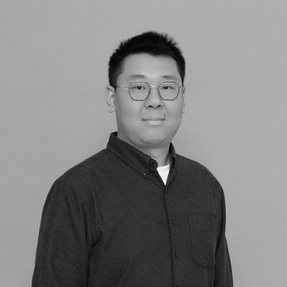

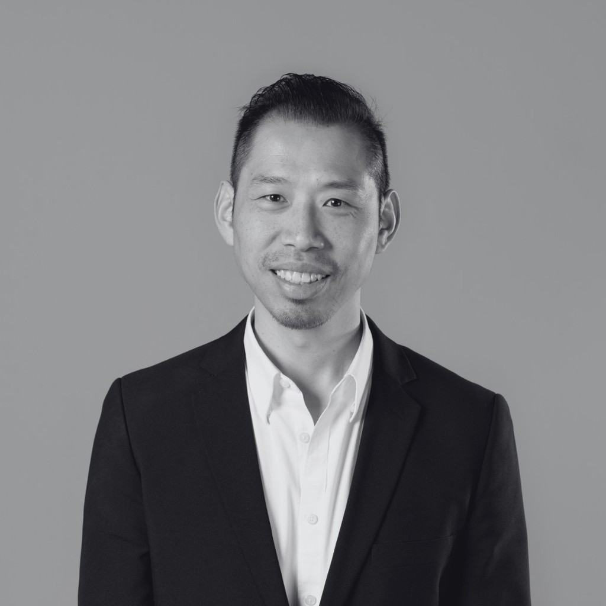

[Carson Li](https://www.sfu.ca/agritech-innovation/about-us/team/carson-li.html) ([BCCAI](https://www.sfu.ca/agritech-innovation.html)) suggested an outline for this talk

[Ian Chan](https://www.linkedin.com/in/ianychan/?originalSubdomain=ca) ([BCCAI](https://www.sfu.ca/agritech-innovation.html)) provided copious feedback